# ArviZ Quickstart

Note

This tutorial is adapted from [ArviZ's quickstart](https://python.arviz.org/en/latest/getting_started/Introduction.html).

## Setup

Here we add the necessary packages for this notebook and load a few we will use throughout.

```julia
using ArviZ, ArviZPythonPlots, Distributions, LinearAlgebra, Random, StanSample, Turing
```

```julia
# ArviZPythonPlots ships with style sheets!
use_style("arviz-darkgrid")
```

## Get started with plotting

To plot with ArviZ, we need to load the ArviZPythonPlots package. ArviZ is designed to be used with libraries like [Stan](https://github.com/StanJulia/Stan.jl), [Turing.jl](https://turinglang.org), and Soss.jl but works fine with raw arrays.

```julia
rng1 = Random.MersenneTwister(37772);
```

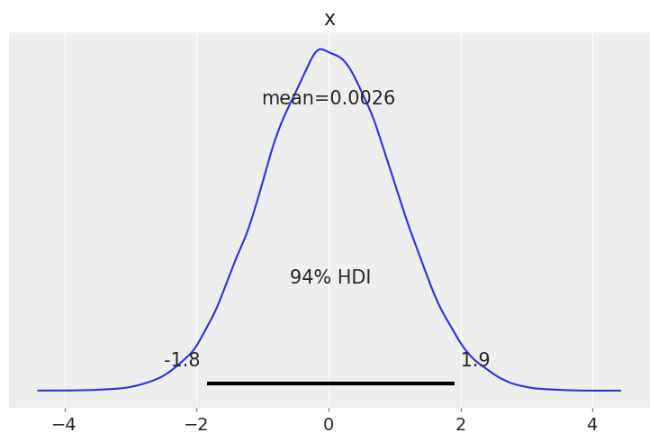

```julia
begin
    plot_posterior(randn(rng1, 100_000))
    gcf()
end
```

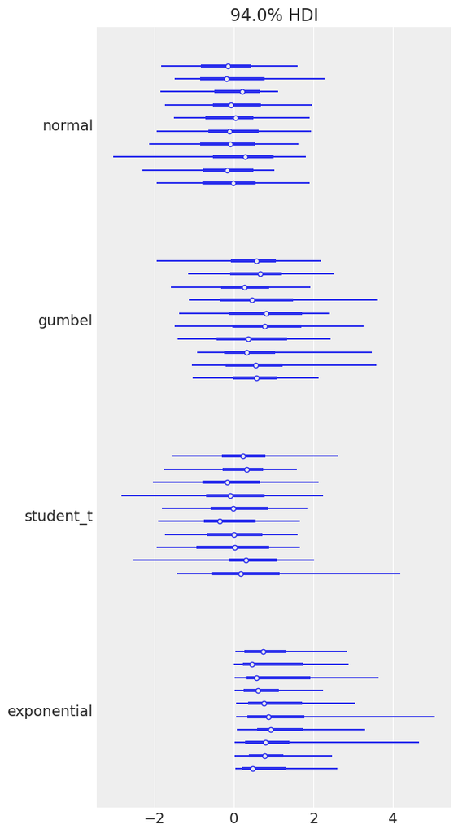

```julia
let
    s = (50, 10)
    plot_forest((
        normal=randn(rng1, s),
        gumbel=rand(rng1, Gumbel(), s),
        student_t=rand(rng1, TDist(6), s),
        exponential=rand(rng1, Exponential(), s),
    ),)
    gcf()
end
```

## Plotting with MCMCChains.jl's `Chains` objects produced by Turing.jl

ArviZ is designed to work well with high dimensional, labelled data. Consider the [eight schools model](https://statmodeling.stat.columbia.edu/2014/01/21/everything-need-know-bayesian-statistics-learned-eight-schools/), which roughly tries to measure the effectiveness of SAT classes at eight different schools. To show off ArviZ's labelling, I give the schools the names of [a different eight schools](https://en.wikipedia.org/wiki/Eight_Schools_Association).

This model is small enough to write down, is hierarchical, and uses labelling. Additionally, a centered parameterization causes [divergences](https://mc-stan.org/users/documentation/case-studies/divergences_and_bias.html) (which are interesting for illustration).

First we create our data and set some sampling parameters.

```julia
begin
    J = 8
    y = [28.0, 8.0, -3.0, 7.0, -1.0, 1.0, 18.0, 12.0]
    σ = [15.0, 10.0, 16.0, 11.0, 9.0, 11.0, 10.0, 18.0]
    schools = [
        "Choate",
        "Deerfield",
        "Phillips Andover",
        "Phillips Exeter",
        "Hotchkiss",
        "Lawrenceville",
        "St. Paul's",
        "Mt. Hermon",
    ]
    ndraws = 1_000
    ndraws_warmup = 1_000
    nchains = 4
end;
```

Now we write and run the model using Turing:

```julia
Turing.@model function model_turing(y, σ, J=length(y))
    μ ~ Normal(0, 5)
    τ ~ truncated(Cauchy(0, 5), 0, Inf)
    θ ~ filldist(Normal(μ, τ), J)
    for i in 1:J
        y[i] ~ Normal(θ[i], σ[i])
    end
end
```

```
model_turing (generic function with 4 methods)
```

```julia
rng2 = Random.MersenneTwister(16653);
```

```julia
begin
    param_mod_turing = model_turing(y, σ)
    sampler = NUTS(ndraws_warmup, 0.8)

    turing_chns = Turing.sample(
        rng2, model_turing(y, σ), sampler, MCMCThreads(), ndraws, nchains
    )
end;
```

Most ArviZ functions work fine with `Chains` objects from Turing:

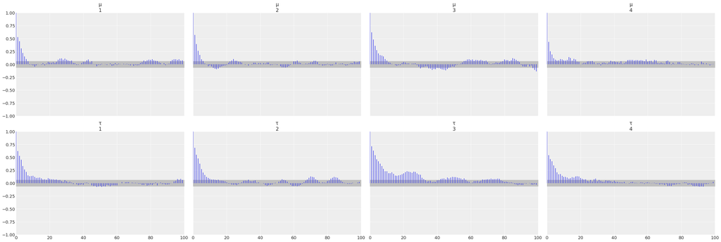

```julia
begin
    plot_autocorr(turing_chns; var_names=(:μ, :τ))
    gcf()
end
```

### Convert to `InferenceData`

For much more powerful querying, analysis and plotting, we can use built-in ArviZ utilities to convert `Chains` objects to multidimensional data structures with named dimensions and indices. Note that for such dimensions, the information is not contained in `Chains`, so we need to provide it.

ArviZ is built to work with [`InferenceData`](https://julia.arviz.org/InferenceObjects/stable/inference_data), and the more *groups* it has access to, the more powerful analyses it can perform.

```julia
idata_turing_post = from_mcmcchains(
    turing_chns;
    coords=(; school=schools),
    dims=NamedTuple(k => (:school,) for k in (:y, :σ, :θ)),
    library="Turing",
)
```

InferenceData

**posterior**

```
╭──────────────────╮
│ 1000×4×8 Dataset │
├──────────────────┴───────────────────────────────────────────────────── dims ┐
  ↓ draw  ,
  → chain ,
  ↗ school Categorical{String} [Choate, Deerfield, …, St. Paul's, Mt. Hermon] Unordered
├────────────────────────────────────────────────────────────────────── layers ┤
  :μ eltype: Float64 dims: draw, chain size: 1000×4
  :τ eltype: Float64 dims: draw, chain size: 1000×4
  :θ eltype: Float64 dims: draw, chain, school size: 1000×4×8
├──────────────────────────────────────────────────────────────────── metadata ┤
  Dict{String, Any} with 2 entries:
  "created_at" => "2024-08-11T08:51:56.288"
  "inference_library" => "Turing"
```

**sample_stats**

```
╭────────────────╮
│ 1000×4 Dataset │
├────────────────┴ dims ┐
  ↓ draw, → chain
├─────────────────┴───────────────────────────────────────── layers ┐
  :energy           eltype: Float64 dims: draw, chain size: 1000×4
  :n_steps          eltype: Int64 dims: draw, chain size: 1000×4
  :diverging        eltype: Bool dims: draw, chain size: 1000×4
  :max_energy_error eltype: Float64 dims: draw, chain size: 1000×4
  :energy_error     eltype: Float64 dims: draw, chain size: 1000×4
  :is_accept        eltype: Bool dims: draw, chain size: 1000×4
  :log_density      eltype: Float64 dims: draw, chain size: 1000×4
  :tree_depth       eltype: Int64 dims: draw, chain size: 1000×4
  :step_size        eltype: Float64 dims: draw, chain size: 1000×4
  :acceptance_rate  eltype: Float64 dims: draw, chain size: 1000×4
  :lp               eltype: Float64 dims: draw, chain size: 1000×4
  :step_size_nom    eltype: Float64 dims: draw, chain size: 1000×4
├───────────────────────────────────────────────────────── metadata ┤
  Dict{String, Any} with 2 entries:
  "created_at" => "2024-08-11T08:51:56.228"
  "inference_library" => "Turing"
```

Each group is an [`ArviZ.Dataset`](https://julia.arviz.org/InferenceObjects/stable/dataset), a `DimensionalData.AbstractDimStack` that can be used identically to a [`DimensionalData.Dimstack`](https://rafaqz.github.io/DimensionalData.jl/stable/reference/#DimensionalData.DimStack). We can view a summary of the dataset.

```julia
idata_turing_post.posterior
```

```
╭──────────────────╮
│ 1000×4×8 Dataset │
├──────────────────┴───────────────────────────────────────────────────────────── dims ┐
  ↓ draw  ,
  → chain ,
  ↗ school Categorical{String} [Choate, Deerfield, …, St. Paul's, Mt. Hermon] Unordered
├────────────────────────────────────────────────────────────────────────────── layers ┤
  :μ eltype: Float64 dims: draw, chain size: 1000×4
  :τ eltype: Float64 dims: draw, chain size: 1000×4
  :θ eltype: Float64 dims: draw, chain, school size: 1000×4×8
├──────────────────────────────────────────────────────────────────────────── metadata ┤
  Dict{String, Any} with 2 entries:
  "created_at"        => "2024-08-11T08:51:56.288"
  "inference_library" => "Turing"
```

Here is a plot of the trace. Note the intelligent labels.

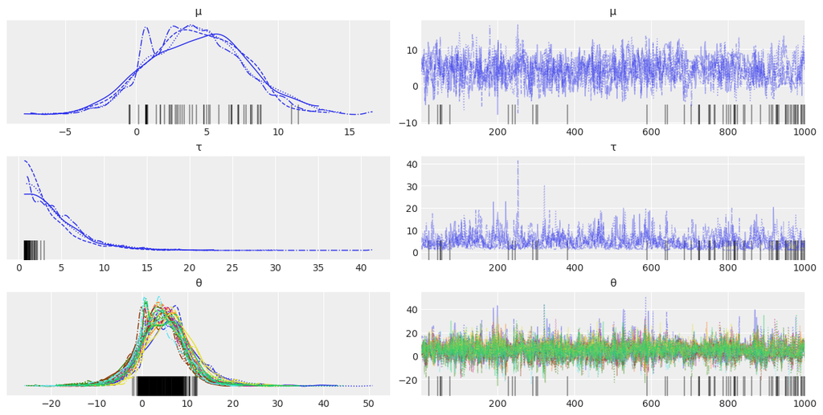

```julia
begin
    plot_trace(idata_turing_post)
    gcf()
end
```

We can also generate summary stats...

```julia
summarystats(idata_turing_post)
```

SummaryStats

|  | mean | std | hdi_3% | hdi_97% | mcse_mean | mcse_std | ess_tail | ess_bulk | rhat |
| --- | --- | --- | --- | --- | --- | --- | --- | --- | --- |
| μ | 4.3 | 3.3 | -1.81 | 10.5 | 0.11 | 0.062 | 1192 | 845 | 1.01 |
| τ | 4.4 | 3.3 | 0.673 | 10.4 | 0.20 | 0.12 | 109 | 115 | 1.05 |
| θ[Choate] | 6.6 | 6.1 | -4.01 | 18.0 | 0.21 | 0.19 | 1627 | 750 | 1.01 |
| θ[Deerfield] | 5.0 | 5.0 | -4.81 | 14.2 | 0.14 | 0.14 | 1952 | 1277 | 1.01 |
| θ[Phillips Andover] | 3.7 | 5.7 | -7.07 | 14.6 | 0.14 | 0.16 | 1979 | 1429 | 1.01 |
| θ[Phillips Exeter] | 4.8 | 5.1 | -4.60 | 14.4 | 0.14 | 0.14 | 2064 | 1178 | 1.00 |
| θ[Hotchkiss] | 3.3 | 4.9 | -6.08 | 12.6 | 0.15 | 0.11 | 1804 | 1098 | 1.01 |
| θ[Lawrenceville] | 3.8 | 5.2 | -6.12 | 13.3 | 0.13 | 0.14 | 1965 | 1331 | 1.00 |
| θ[St. Paul's] | 6.6 | 5.4 | -2.68 | 17.4 | 0.18 | 0.14 | 1842 | 853 | 1.01 |
| θ[Mt. Hermon] | 4.9 | 5.6 | -5.71 | 14.8 | 0.14 | 0.19 | 1794 | 1393 | 1.00 |

...and examine the energy distribution of the Hamiltonian sampler.

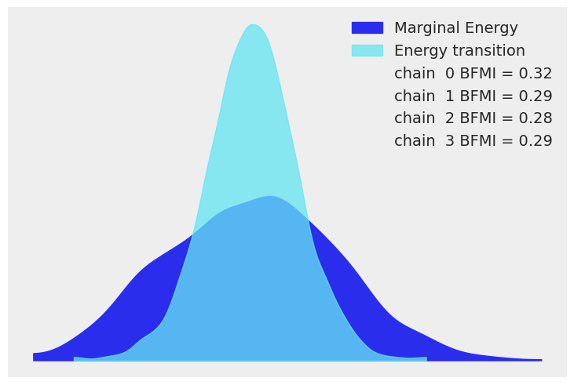

```julia
begin
    plot_energy(idata_turing_post)
    gcf()
end
```

### Additional information in Turing.jl

With a few more steps, we can use Turing to compute additional useful groups to add to the `InferenceData`.

To sample from the prior, one simply calls `sample` but with the `Prior` sampler:

```julia
prior = Turing.sample(rng2, param_mod_turing, Prior(), ndraws);
```

To draw from the prior and posterior predictive distributions we can instantiate a "predictive model", i.e. a Turing model but with the observations set to `missing`, and then calling `predict` on the predictive model and the previously drawn samples:

```julia
begin
    # Instantiate the predictive model
    param_mod_predict = model_turing(similar(y, Missing), σ)
    # and then sample!
    prior_predictive = Turing.predict(rng2, param_mod_predict, prior)
    posterior_predictive = Turing.predict(rng2, param_mod_predict, turing_chns)
end;
```

And to extract the pointwise log-likelihoods, which is useful if you want to compute metrics such as [`loo`](https://julia.arviz.org/ArviZ/stable/api/stats/#PosteriorStats.loo),

```julia
log_likelihood = let
    log_likelihood = Turing.pointwise_loglikelihoods(
        param_mod_turing, MCMCChains.get_sections(turing_chns, :parameters)
    )
    # Ensure the ordering of the loglikelihoods matches the ordering of `posterior_predictive`
    ynames = string.(keys(posterior_predictive))
    log_likelihood_y = getindex.(Ref(log_likelihood), ynames)
    (; y=cat(log_likelihood_y...; dims=3))
end;
```

This can then be included in the [`from_mcmcchains`](https://julia.arviz.org/ArviZ/stable/api/data/#ArviZ.from_mcmcchains) call from above:

```julia
idata_turing = from_mcmcchains(
    turing_chns;
    posterior_predictive,
    log_likelihood,
    prior,
    prior_predictive,
    observed_data=(; y),
    coords=(; school=schools),
    dims=NamedTuple(k => (:school,) for k in (:y, :σ, :θ)),
    library=Turing,
)
```

InferenceData

**posterior**

```
╭──────────────────╮
│ 1000×4×8 Dataset │
├──────────────────┴───────────────────────────────────────────────────── dims ┐
  ↓ draw  ,
  → chain ,
  ↗ school Categorical{String} [Choate, Deerfield, …, St. Paul's, Mt. Hermon] Unordered
├────────────────────────────────────────────────────────────────────── layers ┤
  :μ eltype: Float64 dims: draw, chain size: 1000×4
  :τ eltype: Float64 dims: draw, chain size: 1000×4
  :θ eltype: Float64 dims: draw, chain, school size: 1000×4×8
├──────────────────────────────────────────────────────────────────── metadata ┤
  Dict{String, Any} with 3 entries:
  "created_at" => "2024-08-11T08:52:27.34"
  "inference_library_version" => "0.30.9"
  "inference_library" => "Turing"
```

**posterior_predictive**

```
╭──────────────────╮
│ 1000×4×8 Dataset │
├──────────────────┴───────────────────────────────────────────────────── dims ┐
  ↓ draw  ,
  → chain ,
  ↗ school Categorical{String} [Choate, Deerfield, …, St. Paul's, Mt. Hermon] Unordered
├────────────────────────────────────────────────────────────────────── layers ┤
  :y eltype: Float64 dims: draw, chain, school size: 1000×4×8
├──────────────────────────────────────────────────────────────────── metadata ┤
  Dict{String, Any} with 3 entries:
  "created_at" => "2024-08-11T08:52:27.069"
  "inference_library_version" => "0.30.9"
  "inference_library" => "Turing"
```

**log_likelihood**

```
╭──────────────────╮
│ 1000×4×8 Dataset │
├──────────────────┴───────────────────────────────────────────────────── dims ┐
  ↓ draw  ,
  → chain ,
  ↗ school Categorical{String} [Choate, Deerfield, …, St. Paul's, Mt. Hermon] Unordered
├────────────────────────────────────────────────────────────────────── layers ┤
  :y eltype: Float64 dims: draw, chain, school size: 1000×4×8
├──────────────────────────────────────────────────────────────────── metadata ┤
  Dict{String, Any} with 3 entries:
  "created_at" => "2024-08-11T08:52:27.211"
  "inference_library_version" => "0.30.9"
  "inference_library" => "Turing"
```

**sample_stats**

```
╭────────────────╮
│ 1000×4 Dataset │
├────────────────┴ dims ┐
  ↓ draw, → chain
├─────────────────┴───────────────────────────────────────── layers ┐
  :energy           eltype: Float64 dims: draw, chain size: 1000×4
  :n_steps          eltype: Int64 dims: draw, chain size: 1000×4
  :diverging        eltype: Bool dims: draw, chain size: 1000×4
  :max_energy_error eltype: Float64 dims: draw, chain size: 1000×4
  :energy_error     eltype: Float64 dims: draw, chain size: 1000×4
  :is_accept        eltype: Bool dims: draw, chain size: 1000×4
  :log_density      eltype: Float64 dims: draw, chain size: 1000×4
  :tree_depth       eltype: Int64 dims: draw, chain size: 1000×4
  :step_size        eltype: Float64 dims: draw, chain size: 1000×4
  :acceptance_rate  eltype: Float64 dims: draw, chain size: 1000×4
  :lp               eltype: Float64 dims: draw, chain size: 1000×4
  :step_size_nom    eltype: Float64 dims: draw, chain size: 1000×4
├───────────────────────────────────────────────────────── metadata ┤
  Dict{String, Any} with 3 entries:
  "created_at" => "2024-08-11T08:52:27.34"
  "inference_library_version" => "0.30.9"
  "inference_library" => "Turing"
```

**prior**

```
╭──────────────────╮
│ 1000×1×8 Dataset │
├──────────────────┴───────────────────────────────────────────────────── dims ┐
  ↓ draw  ,
  → chain ,
  ↗ school Categorical{String} [Choate, Deerfield, …, St. Paul's, Mt. Hermon] Unordered
├────────────────────────────────────────────────────────────────────── layers ┤
  :μ eltype: Float64 dims: draw, chain size: 1000×1
  :τ eltype: Float64 dims: draw, chain size: 1000×1
  :θ eltype: Float64 dims: draw, chain, school size: 1000×1×8
├──────────────────────────────────────────────────────────────────── metadata ┤
  Dict{String, Any} with 3 entries:
  "created_at" => "2024-08-11T08:52:27.799"
  "inference_library_version" => "0.30.9"
  "inference_library" => "Turing"
```

**prior_predictive**

```
╭──────────────────╮
│ 1000×1×8 Dataset │
├──────────────────┴───────────────────────────────────────────────────── dims ┐
  ↓ draw  ,
  → chain ,
  ↗ school Categorical{String} [Choate, Deerfield, …, St. Paul's, Mt. Hermon] Unordered
├────────────────────────────────────────────────────────────────────── layers ┤
  :y eltype: Float64 dims: draw, chain, school size: 1000×1×8
├──────────────────────────────────────────────────────────────────── metadata ┤
  Dict{String, Any} with 3 entries:
  "created_at" => "2024-08-11T08:52:27.661"
  "inference_library_version" => "0.30.9"
  "inference_library" => "Turing"
```

**sample_stats_prior**

```
╭────────────────╮
│ 1000×1 Dataset │
├────────────────┴ dims ┐
  ↓ draw, → chain
├─────────────────┴─────────────────────────── layers ┐
  :lp eltype: Float64 dims: draw, chain size: 1000×1
├─────────────────────────────────────────── metadata ┤
  Dict{String, Any} with 3 entries:
  "created_at" => "2024-08-11T08:52:27.751"
  "inference_library_version" => "0.30.9"
  "inference_library" => "Turing"
```

**observed_data**

```
╭───────────────────╮
│ 8-element Dataset │
├───────────────────┴──────────────────────────────────────────────────── dims ┐
  ↓ school Categorical{String} [Choate, Deerfield, …, St. Paul's, Mt. Hermon] Unordered
├────────────────────────────────────────────────────────────────────── layers ┤
  :y eltype: Float64 dims: school size: 8
├──────────────────────────────────────────────────────────────────── metadata ┤
  Dict{String, Any} with 3 entries:
  "created_at" => "2024-08-11T08:52:27.972"
  "inference_library_version" => "0.30.9"
  "inference_library" => "Turing"
```

```julia
loo(idata_turing) # higher ELPD is better
```

```
PSISLOOResult with estimates
 elpd  elpd_mcse    p  p_mcse
  -31        1.4  1.0    0.33

and PSISResult with 1000 draws, 4 chains, and 8 parameters
Pareto shape (k) diagnostic values:
                    Count      Min. ESS
 (-Inf, 0.5]  good  5 (62.5%)  404
  (0.5, 0.7]  okay  3 (37.5%)  788
```

If the model is well-calibrated, i.e. it replicates the true generative process well, the CDF of the pointwise LOO values should be similarly distributed to a uniform distribution. This can be inspected visually:

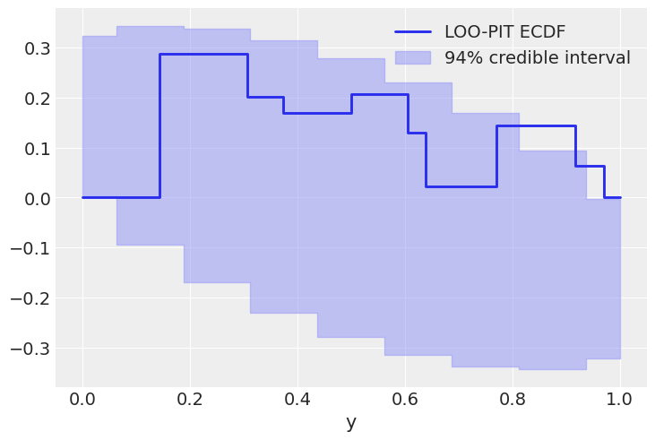

```julia
begin
    plot_loo_pit(idata_turing; y=:y, ecdf=true)
    gcf()
end
```

## Plotting with Stan.jl outputs

StanSample.jl comes with built-in support for producing `InferenceData` outputs.

Here is the same centered eight schools model in Stan:

```julia
begin
    schools_code = """
    data {
      int<lower=0> J;
      array[J] real y;
      array[J] real<lower=0> sigma;
    }

    parameters {
      real mu;
      real<lower=0> tau;
      array[J] real theta;
    }

    model {
      mu ~ normal(0, 5);
      tau ~ cauchy(0, 5);
      theta ~ normal(mu, tau);
      y ~ normal(theta, sigma);
    }

    generated quantities {
        vector[J] log_lik;
        vector[J] y_hat;
        for (j in 1:J) {
            log_lik[j] = normal_lpdf(y[j] | theta[j], sigma[j]);
            y_hat[j] = normal_rng(theta[j], sigma[j]);
        }
    }
    """

    schools_data = Dict("J" => J, "y" => y, "sigma" => σ)
    idata_stan = mktempdir() do path
        stan_model = SampleModel("schools", schools_code, path)
        _ = stan_sample(
            stan_model;
            data=schools_data,
            num_chains=nchains,
            num_warmups=ndraws_warmup,
            num_samples=ndraws,
            seed=28983,
            summary=false,
        )
        return StanSample.inferencedata(
            stan_model;
            posterior_predictive_var=:y_hat,
            observed_data=(; y),
            log_likelihood_var=:log_lik,
            coords=(; school=schools),
            dims=NamedTuple(
                k => (:school,) for k in (:y, :sigma, :theta, :log_lik, :y_hat)
            ),
        )
    end
end
```

InferenceData

**posterior**

```
╭──────────────────╮
│ 1000×4×8 Dataset │
├──────────────────┴───────────────────────────────────────────────────── dims ┐
  ↓ draw  ,
  → chain ,
  ↗ school Categorical{String} [Choate, Deerfield, …, St. Paul's, Mt. Hermon] Unordered
├────────────────────────────────────────────────────────────────────── layers ┤
  :mu    eltype: Float64 dims: draw, chain size: 1000×4
  :tau   eltype: Float64 dims: draw, chain size: 1000×4
  :theta eltype: Float64 dims: draw, chain, school size: 1000×4×8
├──────────────────────────────────────────────────────────────────── metadata ┤
  Dict{String, Any} with 1 entry:
  "created_at" => "2024-08-11T08:53:13.351"
```

**posterior_predictive**

```
╭──────────────────╮
│ 1000×4×8 Dataset │
├──────────────────┴───────────────────────────────────────────────────── dims ┐
  ↓ draw  ,
  → chain ,
  ↗ school Categorical{String} [Choate, Deerfield, …, St. Paul's, Mt. Hermon] Unordered
├────────────────────────────────────────────────────────────────────── layers ┤
  :y_hat eltype: Float64 dims: draw, chain, school size: 1000×4×8
├──────────────────────────────────────────────────────────────────── metadata ┤
  Dict{String, Any} with 1 entry:
  "created_at" => "2024-08-11T08:53:12.89"
```

**log_likelihood**

```
╭──────────────────╮
│ 1000×4×8 Dataset │
├──────────────────┴───────────────────────────────────────────────────── dims ┐
  ↓ draw  ,
  → chain ,
  ↗ school Categorical{String} [Choate, Deerfield, …, St. Paul's, Mt. Hermon] Unordered
├────────────────────────────────────────────────────────────────────── layers ┤
  :log_lik eltype: Float64 dims: draw, chain, school size: 1000×4×8
├──────────────────────────────────────────────────────────────────── metadata ┤
  Dict{String, Any} with 1 entry:
  "created_at" => "2024-08-11T08:53:13.273"
```

**sample_stats**

```
╭────────────────╮
│ 1000×4 Dataset │
├────────────────┴ dims ┐
  ↓ draw, → chain
├─────────────────┴──────────────────────────────────────── layers ┐
  :tree_depth      eltype: Int64 dims: draw, chain size: 1000×4
  :energy          eltype: Float64 dims: draw, chain size: 1000×4
  :diverging       eltype: Bool dims: draw, chain size: 1000×4
  :acceptance_rate eltype: Float64 dims: draw, chain size: 1000×4
  :n_steps         eltype: Int64 dims: draw, chain size: 1000×4
  :lp              eltype: Float64 dims: draw, chain size: 1000×4
  :step_size       eltype: Float64 dims: draw, chain size: 1000×4
├──────────────────────────────────────────────────────── metadata ┤
  Dict{String, Any} with 1 entry:
  "created_at" => "2024-08-11T08:53:12.995"
```

**observed_data**

```
╭───────────────────╮
│ 8-element Dataset │
├───────────────────┴──────────────────────────────────────────────────── dims ┐
  ↓ school Categorical{String} [Choate, Deerfield, …, St. Paul's, Mt. Hermon] Unordered
├────────────────────────────────────────────────────────────────────── layers ┤
  :y eltype: Float64 dims: school size: 8
├──────────────────────────────────────────────────────────────────── metadata ┤
  Dict{String, Any} with 1 entry:
  "created_at" => "2024-08-11T08:53:13.399"
```

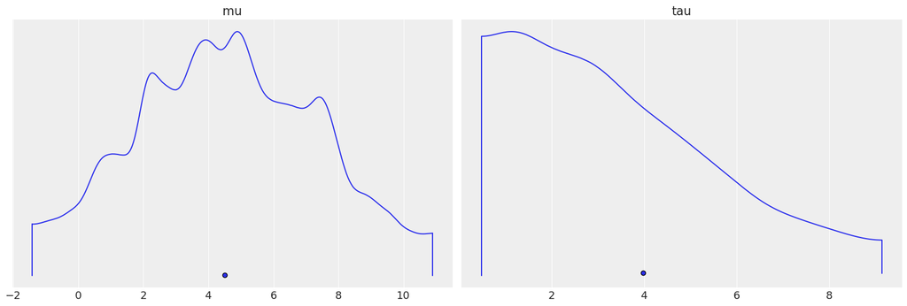

```julia
begin
    plot_density(idata_stan; var_names=(:mu, :tau))
    gcf()
end
```

Here is a plot showing where the Hamiltonian sampler had divergences:

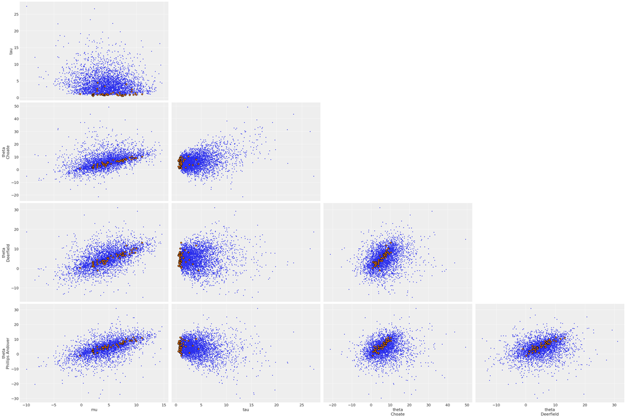

```julia
begin
    plot_pair(
        idata_stan;
        coords=Dict(:school => ["Choate", "Deerfield", "Phillips Andover"]),
        divergences=true,
    )
    gcf()
end
```

## Environment

```julia
using PlutoUI
```

```julia
using Pkg, InteractiveUtils
```

```julia
with_terminal(Pkg.status; color=false)
```

```
Status `~/work/ArviZ.jl/ArviZ.jl/docs/Project.toml`
⌅ [cbdf2221] AlgebraOfGraphics v0.6.20
  [131c737c] ArviZ v0.12.1 `~/work/ArviZ.jl/ArviZ.jl`
  [2f96bb34] ArviZExampleData v0.1.11
  [4a6e88f0] ArviZPythonPlots v0.1.7
⌅ [13f3f980] CairoMakie v0.11.11
  [a93c6f00] DataFrames v1.6.1
  [0703355e] DimensionalData v0.27.6
  [31c24e10] Distributions v0.25.110
  [e30172f5] Documenter v1.5.0
  [f6006082] EvoTrees v0.16.7
  [b5cf5a8d] InferenceObjects v0.4.2
  [be115224] MCMCDiagnosticTools v0.3.10
  [a7f614a8] MLJBase v1.7.0
  [614be32b] MLJIteration v0.6.2
  [ce719bf2] PSIS v0.9.5
  [359b1769] PlutoStaticHTML v6.0.27
  [7f904dfe] PlutoUI v0.7.59
  [7f36be82] PosteriorStats v0.2.5
  [c1514b29] StanSample v7.10.1
  [a19d573c] StatisticalMeasures v0.1.6
  [2913bbd2] StatsBase v0.34.3
⌅ [fce5fe82] Turing v0.30.9
  [f43a241f] Downloads v1.6.0
  [37e2e46d] LinearAlgebra
  [10745b16] Statistics v1.10.0
Info Packages marked with ⌅ have new versions available but compatibility constraints restrict them from upgrading. To see why use `status --outdated`
```

```julia
with_terminal(versioninfo)
```

```
Julia Version 1.10.4
Commit 48d4fd48430 (2024-06-04 10:41 UTC)
Build Info:
  Official https://julialang.org/ release
Platform Info:
  OS: Linux (x86_64-linux-gnu)
  CPU: 4 × AMD EPYC 7763 64-Core Processor
  WORD_SIZE: 64
  LIBM: libopenlibm
  LLVM: libLLVM-15.0.7 (ORCJIT, znver3)
Threads: 2 default, 0 interactive, 1 GC (on 4 virtual cores)
Environment:
  JULIA_PKG_SERVER_REGISTRY_PREFERENCE = eager
  JULIA_NUM_THREADS = 2
  JULIA_REVISE_WORKER_ONLY = 1
  JULIA_PYTHONCALL_EXE = /home/runner/work/ArviZ.jl/ArviZ.jl/docs/.CondaPkg/env/bin/python
```